# langley1_OriginalHomeworkCode_02

# **Homework 2: Titis in the Mist**

This is my code for [Homework 2](https://fuzzyatelin.github.io/bioanth-stats/homework-02.html)

> Every Saturday morning, at the same time, a primatologist goes and sits in the forest to listen for titi monkey calls, counting the number of calls they hear in a 2 hour window from 5am to 7am. Based on previous knowledge, she believes that the mean number of calls she will hear in that time is exactly 15. Let X represent the appropriate Poisson random variable of the number of calls heard in each monitoring session.

We want to use the Poisson Distribution because it is often used to model open ended counts of independently occuring events, i.e the number of times a monkey calls in a given interval

The Poisson distribution function, ppois(), returns the value of the cumulative distribution function, i.e., the probability of observing up to and including a specific number of events in the given interval (so this relates to the question)

## Question 1

What is the probability that she will hear more than 8 calls during any given session?

```r
#We know that the mean number of calls is 15, so lambda= 15
#We know that the number of successes should be >8 but we can't put "9:infinity" for our q value... but we can find the probability for 0:8 and then take the inverse of that for >8... lets try it!

q<- 0:8
l<- 15
prob1.2<- ppois(q, l, lower.tail = TRUE, log.p = FALSE)
prob1.2 #3.059023e-07 4.894437e-06 3.930845e-05 2.113785e-04 8.566412e-04 2.792429e-03 7.631900e-03 1.800219e-02 3.744649e-02
```

```
## [1] 3.059023e-07 4.894437e-06 3.930845e-05 2.113785e-04 8.566412e-04
## [6] 2.792429e-03 7.631900e-03 1.800219e-02 3.744649e-02
```

```r
#If these numbes above are showing me all of the probabilities for the range of 0 - 8 calls, then I'm going to add them up and take the inverse of that number
ProbSum<- sum(prob1.2) #0.067
CallsProb<- 1 - ProbSum
CallsProb #The probability she will hear more than 8 calls = 0.933
```

```
## [1] 0.9330145
```

```r
#Overall, I have absolutely no idea if this is right. This probability seems too high to me.
```

## Question 2

### 2) What is the probability that she will hear no calls in a session?

```r
#Now we need to adjust our q value to 0 but we can keep lamda at 15
x<- 0
l<- 15
prob2<- dpois(x, l)
prob2
```

```
## [1] 3.059023e-07
```

## Question 3

### 3) What is the probability that she will hear exactly 3 calls in a session?

```r
#Now we can change our q value to equal 3 (note: the q value doesn't always need to be a range of numbers i.e. 0:100)
q<- 3
l<- 15
prob3<- ppois(q, lambda = l)
prob3
```

```
## [1] 0.0002113785
```

## Question 4

### 4) Plot the relevant Poisson mass function over the values in range 0 ≤ x ≤ 30.

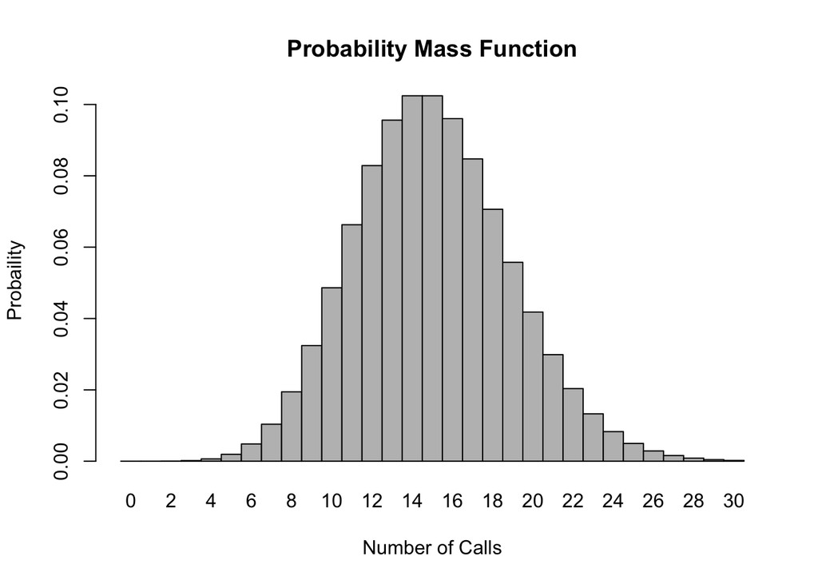

```r
x <- 0:30
l = 15
prob4<- dpois(x=x,lambda=l)
barplot(prob4,names.arg=x,space=0,xlab="Number of Calls",ylab="Probaility",main="Probability Mass Function")
```